# Tarea 1 - Semestre Primavera 2021

Michael Clemans - Jorge Manriquez - Sebastián Urbina

6 de Septiembre de 2021

**Universidad de Chile**

**Ingeniería Industrial**

**IN5602**: Marketing II

**Prof**: Pedro Arana

**Auxs**: Renato Cerda, Gabriela Mora, Ángelo Muñoz, Rafael Tiara

```r
train <- read.csv("train.csv")
meal_info <- read.csv("meal_info.csv")
fulfilment_center_info <- read.csv("fulfilment_center_info.csv")

df <- inner_join(train, meal_info)
df <- inner_join(df, fulfilment_center_info)
df$week = as.factor(df$week)
df$center_id = as.factor(df$center_id)
df$meal_id = as.factor(df$meal_id)
df$emailer_for_promotion  = as.factor(df$emailer_for_promotion)
df$homepage_featured = as.factor(df$homepage_featured)
df$category = as.factor(df$category)
df$cuisine = as.factor(df$cuisine)
df$city_code = as.factor(df$city_code)
df$region_code = as.factor(df$region_code)
df$center_type = as.factor(df$center_type)
```

## Pregunta 1

### ¿Cuál es el tipo de comida y cocina que más vende la compañía?

Para obtener el tipo de comida más vendida, se examina la suma total de num_order respecto a category. Se repite el mismo proceso para cocina, pero usando cuisine en vez de category. Observando el siguiente gráfico se comprueba qué beverages o bebestibles es el tipo de comida más vendida, mientras qué el tipo de comida corresponde a italian.

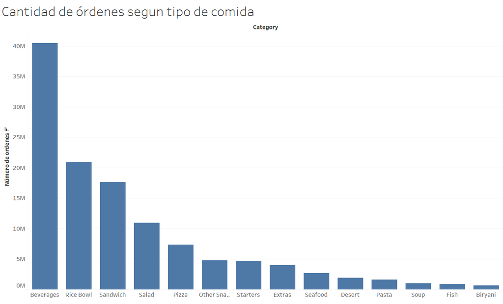

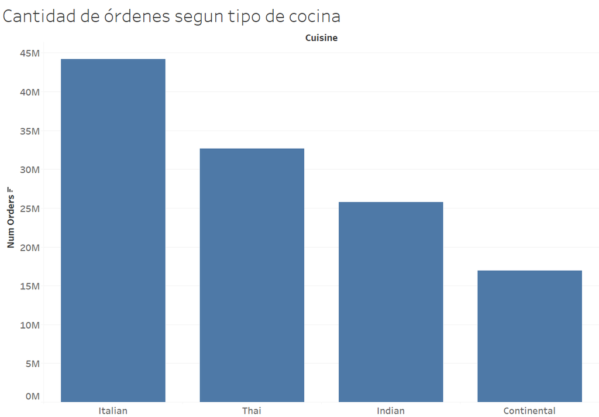

### ¿Coincide con el tipo de comida/cocina que en general más se vende en cada uno de los locales?

Se calcula la suma de num_order, pero ahora por locales y tipo de cocina.

En el primer gráfico se obseerva que efectivamente los bebestibles(color azul) predominan en todos los locales.

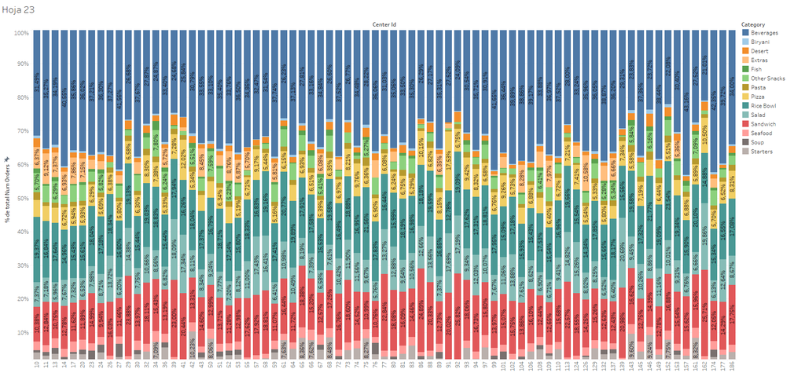

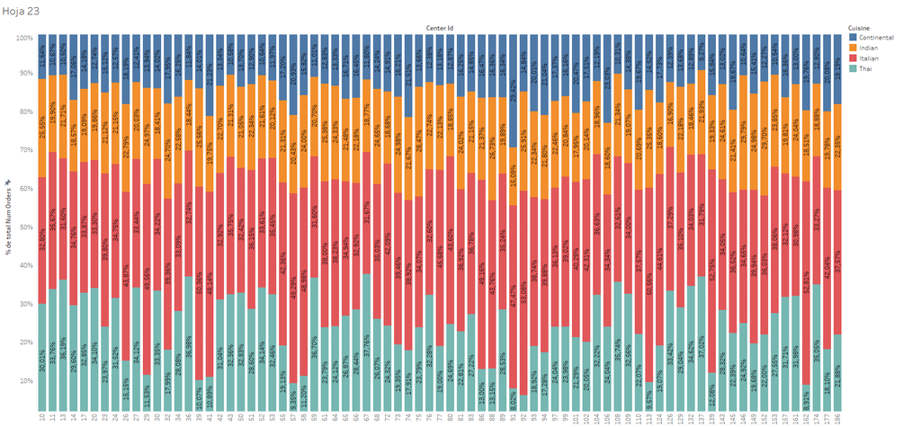

### ¿Qué centro es el que más vende?

Se calcula ahora la venta como la suma de num_order por el precio pagado por orden para cada uno de los centros. Se observa qué el centro 13 es quien vende más, con una cifra de más de 1100 millones.

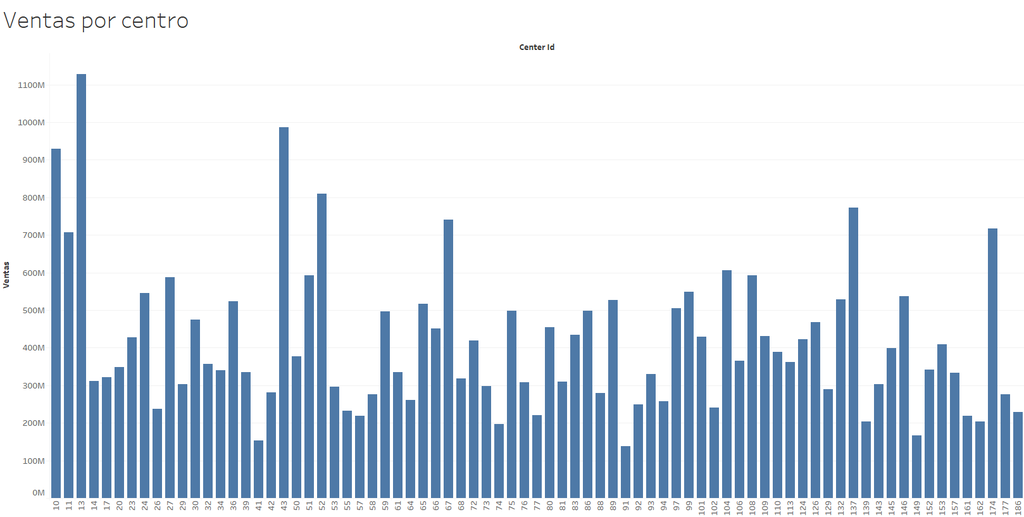

### ¿Qué centro es el que tiene una mayor demanda de pedidos?

Se procede a calcular la cantidad de pedidos como el número de ordenes distintas para cada centro. En otras palabras, la variedad de comidas por cada centro. Se puede observar que los centros que más pedidos tienen son el 89,80,67,53,52,51,43,20,174,137,13,124 y 10, con una cantidad de 51 distintos pedidos

*Nota: Nos pareció mas acorde a definir la “variedad de comidas por centro” en vez de “la demanda de pedidos”, ya que el profe lo dió a entender así en el foro(Pedidos el número de tipos distintos de ordenes (meal_id))

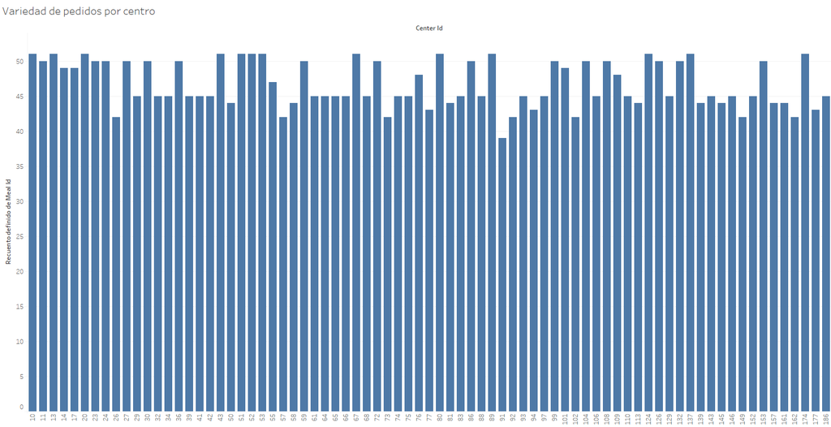

### ¿Cúal es el centro que tiene la mejor relación Ventas/Pedidos?

Calculamos el cociente entre ambas métricas obtenidas anteriormentes, osea, ventas como la suma del producto de `num_order` y `checkout_price` por cada centro y la demanda de pedidos como el conteo de comidas distintas por centros. Dicho esto, se puede observar que el `centro 13` es el que tiene la mayor relación Ventas/Pedidos.

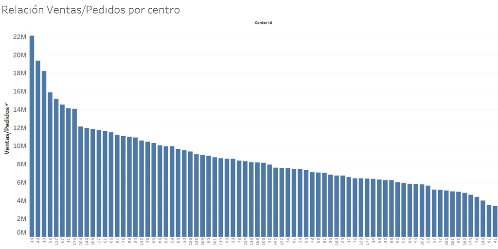

### ¿Existe algún tipo de correlación entre la cantidad de comidas vendidas en un local y el

tamaño del área de operación que tiene este(op area)?

Se puede observar graficamente que existe cierta tendencia entre la relación entre el área operativa y el total de ordenes, aunque son pocos locales con áreas operativas superiores a 630mil[$m^2$]. Para obtener un valor más preciso, calculamos la correlación de pearson entre ambas variables. Obteniéndose un valor de 0.17, el cual es bastante bajo. Por lo que la correlación es bastante pequeña en magnitud.

```r
cor(df$num_orders,df$op_area)
```

```
## [1] 0.1769763
```

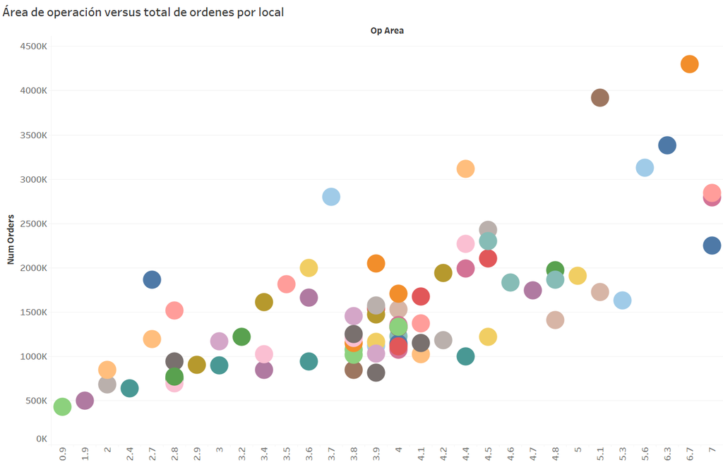

### ¿Hay ciudades que tengan favoritismo por algún tipo de cocina en particular?

Para realizar esto, calculamos el conteo del número de ordenes para cada ciudad por tipo de cocina. Se puede observar que en la mayoría de las ciudades predomina la comida Italiana, la cual obtiene el mayor porcentaje de preferencias. Asimismo, por ejemplo, en la primera ciudad de izquierda a derecha, la número 456, predomina la comida Thai con un 31% de la cantidad de órdenes.

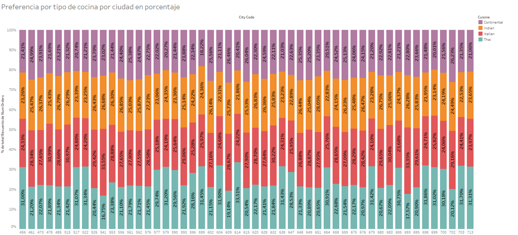